# Differential Expression of *C.bairdi* Genes Across Infection Status and Time Points Using DESeq2

Sam White

This follows the excellent example from Erin Chille’s repo:

https://github.com/echille/Montipora_OA_Development_Timeseries/blob/master/RNAseq_Analyses/DevelopmentxpHTreatment_RNAseqDE.html

Load libraries:

```r
library("DESeq2")
library("tidyverse")
library("dplyr")
library("pheatmap")
library("RColorBrewer")
library("genefilter")
library("ggplot2")
library("gplots")
library("limma")
library("spdep")
library("adegenet")
library("tximport")
```

#### Gene count data were generated using [Salmon](https://combine-lab.github.io/salmon/). See [my notebook entry from 20200429](https://robertslab.github.io/sams-notebook/2020/04/29/Transcript-Abundance-C.bairdi-Alignment-free-with-Salmon-Using-2020-GW-Data-on-Mox.html) for more info.

Examine quant file layouts:

```bash
head ../data/72_quant.sf | column -t
```

```
## Name                      Length  EffectiveLength  TPM         NumReads
## TRINITY_DN21551_c1_g1_i1  696     548.679          565.728499  954.775
## TRINITY_DN21515_c0_g1_i1  207     74.525           0.000000    0.000
## TRINITY_DN21560_c0_g1_i1  501     353.939          383.030242  417.000
## TRINITY_DN21562_c0_g1_i1  226     89.345           0.000000    0.000
## TRINITY_DN21482_c0_g1_i1  249     108.821          0.000000    0.000
## TRINITY_DN21536_c0_g1_i1  223     86.935           0.000000    0.000
## TRINITY_DN21528_c0_g1_i1  328     183.014          0.000000    0.000
## TRINITY_DN21555_c0_g1_i1  266     124.045          0.000000    0.000
## TRINITY_DN21564_c1_g1_i1  1470    1322.666         21.875859   89.000
```

Import sample info:

```r
treatmentinfo <- read.csv("../data/cbai_2020gw_rnaseq_sample_info.csv", header = TRUE, sep = ",")
treatmentinfo
```

```
##    sample_id day infection_status temperature
## 1        113  D9       uninfected     ambient
## 2        118  D9         infected     ambient
## 3        127  D9         infected     ambient
## 4        132  D9         infected     ambient
## 5        151  D9         infected     ambient
## 6        173  D9         infected     ambient
## 7        178  D9         infected     ambient
## 8        221 D12       uninfected        cold
## 9        222 D12       uninfected        cold
## 10       254 D12         infected        cold
## 11       272 D12         infected        warm
## 12       280 D12         infected        warm
## 13       294 D12         infected        warm
## 14       334 D12         infected     ambient
## 15       349 D12         infected     ambient
## 16       359 D12         infected     ambient
## 17       425 D26       uninfected        cold
## 18       427 D26       uninfected        cold
## 19       445 D26         infected        cold
## 20       463 D26         infected     ambient
## 21       481 D26         infected     ambient
## 22       485 D26         infected     ambient
## 23        72  D9         infected     ambient
## 24        73  D9       uninfected     ambient
```

Import gene count matrix:

```r
# Read in salmon gene count data
# First column has no label, so use "empty" row.names to assign Trinity gene IDs to row names
gcount <- read.csv("../data/salmon.gene.counts.matrix",
                   header = TRUE,
                   row.names = "",
                   check.names = FALSE,
                   sep = "\t")
head(gcount)
```

```
##                    294_quant 254_quant 280_quant 485_quant 481_quant 173_quant
## TRINITY_DN0_c0_g1       3.37      0.00      0.00      6.11      0.00   5333.68
## TRINITY_DN0_c0_g2       0.00      0.88      4.09      6.10      5.44  11274.66
## TRINITY_DN0_c10_g1      0.00      0.00      0.00      0.00      0.00      0.00
## TRINITY_DN0_c10_g2      0.00      0.00      0.00      0.00      0.00      0.00
## TRINITY_DN0_c11_g1     12.24      0.00      0.00     21.95      0.00      0.00
## TRINITY_DN0_c12_g1      0.00      0.00      0.00      0.00      0.00      0.00
##                    222_quant 151_quant 272_quant 132_quant 127_quant 73_quant
## TRINITY_DN0_c0_g1       0.00   1306.54      0.00   1741.68    309.64     1.00
## TRINITY_DN0_c0_g2       1.13   2170.86      1.42   4965.42    877.10     1.35
## TRINITY_DN0_c10_g1      0.00      0.00      0.00      0.00      0.00     0.00
## TRINITY_DN0_c10_g2      0.00      0.00      0.00      0.00      0.00     0.00
## TRINITY_DN0_c11_g1      0.00     12.27      0.00     17.18      0.00     0.00
## TRINITY_DN0_c12_g1      0.00      0.00      0.00      0.00      0.00     0.00
##                    427_quant 118_quant 334_quant 349_quant 425_quant 178_quant
## TRINITY_DN0_c0_g1       0.00      1.98      1.87      2.46         0   1986.74
## TRINITY_DN0_c0_g2       0.51      2.60      3.21      3.43         0   6868.72
## TRINITY_DN0_c10_g1      0.00      0.00      0.00      0.00         0      0.00
## TRINITY_DN0_c10_g2      0.00      0.00      0.00      0.00         0     16.78
## TRINITY_DN0_c11_g1      0.00      0.00      0.00      0.00         0      9.24
## TRINITY_DN0_c12_g1      0.00      0.00      0.00      0.00         0      0.00
##                    72_quant 463_quant 221_quant 445_quant 359_quant 113_quant
## TRINITY_DN0_c0_g1      1.89      2.10      0.00         0         0      1.86
## TRINITY_DN0_c0_g2      0.00      0.84      1.55         0         0      3.80
## TRINITY_DN0_c10_g1     0.00      0.00      0.00         0         0      0.00
## TRINITY_DN0_c10_g2     0.00      0.00      0.00         0         0      0.00
## TRINITY_DN0_c11_g1     0.00      0.00      8.29         0         0     13.36
## TRINITY_DN0_c12_g1     0.00      0.00      0.00         0         0      0.00
```

Round gene counts to integers:

```r
# Round numbers to integers
# The `rownames_to_column` and `column_to_rownames` is needed to preserve gene_id rownames
# when using `mutate_if`
gcount <- gcount %>%
  rownames_to_column('gene_id') %>%
  mutate_if(is.numeric, round, 0) %>%
  column_to_rownames('gene_id')

head(gcount)
```

```
##                    294_quant 254_quant 280_quant 485_quant 481_quant 173_quant
## TRINITY_DN0_c0_g1          3         0         0         6         0      5334
## TRINITY_DN0_c0_g2          0         1         4         6         5     11275
## TRINITY_DN0_c10_g1         0         0         0         0         0         0
## TRINITY_DN0_c10_g2         0         0         0         0         0         0
## TRINITY_DN0_c11_g1        12         0         0        22         0         0
## TRINITY_DN0_c12_g1         0         0         0         0         0         0
##                    222_quant 151_quant 272_quant 132_quant 127_quant 73_quant
## TRINITY_DN0_c0_g1          0      1307         0      1742       310        1
## TRINITY_DN0_c0_g2          1      2171         1      4965       877        1
## TRINITY_DN0_c10_g1         0         0         0         0         0        0
## TRINITY_DN0_c10_g2         0         0         0         0         0        0
## TRINITY_DN0_c11_g1         0        12         0        17         0        0
## TRINITY_DN0_c12_g1         0         0         0         0         0        0
##                    427_quant 118_quant 334_quant 349_quant 425_quant 178_quant
## TRINITY_DN0_c0_g1          0         2         2         2         0      1987
## TRINITY_DN0_c0_g2          1         3         3         3         0      6869
## TRINITY_DN0_c10_g1         0         0         0         0         0         0
## TRINITY_DN0_c10_g2         0         0         0         0         0        17
## TRINITY_DN0_c11_g1         0         0         0         0         0         9
## TRINITY_DN0_c12_g1         0         0         0         0         0         0
##                    72_quant 463_quant 221_quant 445_quant 359_quant 113_quant
## TRINITY_DN0_c0_g1         2         2         0         0         0         2
## TRINITY_DN0_c0_g2         0         1         2         0         0         4
## TRINITY_DN0_c10_g1        0         0         0         0         0         0
## TRINITY_DN0_c10_g2        0         0         0         0         0         0
## TRINITY_DN0_c11_g1        0         0         8         0         0        13
## TRINITY_DN0_c12_g1        0         0         0         0         0         0
```

### Construct DESeq2 dataset

#### Check sample IDs match to conform to DESeq2 naming requirements:

```r
# Ensure all sample IDs in colData are also in CountData and match their orders
# Sort column names
gcount <- gcount[ , order(names(gcount))]

head(gcount)
```

```
##                    113_quant 118_quant 127_quant 132_quant 151_quant 173_quant
## TRINITY_DN0_c0_g1          2         2       310      1742      1307      5334
## TRINITY_DN0_c0_g2          4         3       877      4965      2171     11275
## TRINITY_DN0_c10_g1         0         0         0         0         0         0
## TRINITY_DN0_c10_g2         0         0         0         0         0         0
## TRINITY_DN0_c11_g1        13         0         0        17        12         0
## TRINITY_DN0_c12_g1         0         0         0         0         0         0
##                    178_quant 221_quant 222_quant 254_quant 272_quant 280_quant
## TRINITY_DN0_c0_g1       1987         0         0         0         0         0
## TRINITY_DN0_c0_g2       6869         2         1         1         1         4
## TRINITY_DN0_c10_g1         0         0         0         0         0         0
## TRINITY_DN0_c10_g2        17         0         0         0         0         0
## TRINITY_DN0_c11_g1         9         8         0         0         0         0
## TRINITY_DN0_c12_g1         0         0         0         0         0         0
##                    294_quant 334_quant 349_quant 359_quant 425_quant 427_quant
## TRINITY_DN0_c0_g1          3         2         2         0         0         0
## TRINITY_DN0_c0_g2          0         3         3         0         0         1
## TRINITY_DN0_c10_g1         0         0         0         0         0         0
## TRINITY_DN0_c10_g2         0         0         0         0         0         0
## TRINITY_DN0_c11_g1        12         0         0         0         0         0
## TRINITY_DN0_c12_g1         0         0         0         0         0         0
##                    445_quant 463_quant 481_quant 485_quant 72_quant 73_quant
## TRINITY_DN0_c0_g1          0         2         0         6        2        1
## TRINITY_DN0_c0_g2          0         1         5         6        0        1
## TRINITY_DN0_c10_g1         0         0         0         0        0        0
## TRINITY_DN0_c10_g2         0         0         0         0        0        0
## TRINITY_DN0_c11_g1         0         0         0        22        0        0
## TRINITY_DN0_c12_g1         0         0         0         0        0        0
```

```r
# Remove "_quant" from column names
colnames(gcount) = gsub(pattern = "_quant", replacement = "", colnames(gcount))

head(gcount)
```

```
##                    113 118 127  132  151   173  178 221 222 254 272 280 294 334
## TRINITY_DN0_c0_g1    2   2 310 1742 1307  5334 1987   0   0   0   0   0   3   2
## TRINITY_DN0_c0_g2    4   3 877 4965 2171 11275 6869   2   1   1   1   4   0   3
## TRINITY_DN0_c10_g1   0   0   0    0    0     0    0   0   0   0   0   0   0   0
## TRINITY_DN0_c10_g2   0   0   0    0    0     0   17   0   0   0   0   0   0   0
## TRINITY_DN0_c11_g1  13   0   0   17   12     0    9   8   0   0   0   0  12   0
## TRINITY_DN0_c12_g1   0   0   0    0    0     0    0   0   0   0   0   0   0   0
##                    349 359 425 427 445 463 481 485 72 73
## TRINITY_DN0_c0_g1    2   0   0   0   0   2   0   6  2  1
## TRINITY_DN0_c0_g2    3   0   0   1   0   1   5   6  0  1
## TRINITY_DN0_c10_g1   0   0   0   0   0   0   0   0  0  0
## TRINITY_DN0_c10_g2   0   0   0   0   0   0   0   0  0  0
## TRINITY_DN0_c11_g1   0   0   0   0   0   0   0  22  0  0
## TRINITY_DN0_c12_g1   0   0   0   0   0   0   0   0  0  0
```

```r
rownames(treatmentinfo) <- treatmentinfo$sample_id
colnames(gcount) <- treatmentinfo$sample_id

head(treatmentinfo)
```

```
##     sample_id day infection_status temperature
## 113       113  D9       uninfected     ambient
## 118       118  D9         infected     ambient
## 127       127  D9         infected     ambient
## 132       132  D9         infected     ambient
## 151       151  D9         infected     ambient
## 173       173  D9         infected     ambient
```

```r
head(gcount)
```

```
##                    113 118 127  132  151   173  178 221 222 254 272 280 294 334
## TRINITY_DN0_c0_g1    2   2 310 1742 1307  5334 1987   0   0   0   0   0   3   2
## TRINITY_DN0_c0_g2    4   3 877 4965 2171 11275 6869   2   1   1   1   4   0   3
## TRINITY_DN0_c10_g1   0   0   0    0    0     0    0   0   0   0   0   0   0   0
## TRINITY_DN0_c10_g2   0   0   0    0    0     0   17   0   0   0   0   0   0   0
## TRINITY_DN0_c11_g1  13   0   0   17   12     0    9   8   0   0   0   0  12   0
## TRINITY_DN0_c12_g1   0   0   0    0    0     0    0   0   0   0   0   0   0   0
##                    349 359 425 427 445 463 481 485 72 73
## TRINITY_DN0_c0_g1    2   0   0   0   0   2   0   6  2  1
## TRINITY_DN0_c0_g2    3   0   0   1   0   1   5   6  0  1
## TRINITY_DN0_c10_g1   0   0   0   0   0   0   0   0  0  0
## TRINITY_DN0_c10_g2   0   0   0   0   0   0   0   0  0  0
## TRINITY_DN0_c11_g1   0   0   0   0   0   0   0  22  0  0
## TRINITY_DN0_c12_g1   0   0   0   0   0   0   0   0  0  0
```

```r
# Check row and column names match. Should return "TRUE".
all(rownames(treatmentinfo) %in% colnames(gcount))
```

```
## [1] TRUE
```

```r
all(rownames(treatmentinfo) == colnames(gcount))
```

```
## [1] TRUE
```

#### Construct DESeq2 dataset

Create a DESeqDataSet design from gene count matrix and labels. Here we set the design to look at the interaction of `infection_status` and `day` to test for any differences in gene expression across `infection_status` attributed to `day`.

```r
#Set DESeq2 design
gdds <- DESeqDataSetFromMatrix(countData = gcount,
                              colData = treatmentinfo,
                              design = ~infection_status + day + infection_status:day)
```

### Visualize gene count data

We’re looking to see if the samples of the same infection status and day treatment cluster.

#### Log-transform the count data

First we are going to log-transform the data using a variance stabilizing transforamtion (vst). This is only for visualization purposes. Essentially, this is roughly similar to putting the data on the log2 scale. It will deal with the sampling variability of low counts by calculating within-group variability (if blind=FALSE).

NOTE: Running `rlog` on this data produces the following helpful message from DESeq2:

```
rlog(gdds, blind = FALSE)
the rlog assumes that data is close to a negative binomial distribution, an assumption
which is sometimes not compatible with datasets where many genes have many zero counts
despite a few very large counts.
In this data, for 42% of genes with a sum of normalized counts above 100, it was the case
that a single sample's normalized count made up more than 90% of the sum over all samples.
the threshold for this warning is 10% of genes. See plotSparsity(dds) for a visualization of this.
We recommend instead using the varianceStabilizingTransformation or shifted log (see vignette).
```

```r
gvst <- vst(gdds, blind = FALSE)

head (assay(gvst), 3)
```

```
##                         113      118      127      132      151       173
## TRINITY_DN0_c0_g1  3.384803 3.864162 6.794559 8.532195 7.422953 11.500519
## TRINITY_DN0_c0_g2  3.639386 4.089047 7.715141 9.871407 7.914025 12.952983
## TRINITY_DN0_c10_g1 2.825659 2.825659 2.825659 2.825659 2.825659  2.825659
##                         178      221      222      254      272      280
## TRINITY_DN0_c0_g1  8.193653 2.825659 2.825659 2.825659 2.825659 2.825659
## TRINITY_DN0_c0_g2  9.681224 3.429849 3.283469 3.250968 4.026498 4.147281
## TRINITY_DN0_c10_g1 2.825659 2.825659 2.825659 2.825659 2.825659 2.825659
##                         294      334      349      359      425      427
## TRINITY_DN0_c0_g1  3.406892 3.743807 8.018159 2.825659 2.825659 2.825659
## TRINITY_DN0_c0_g2  2.825659 3.949188 8.438672 2.825659 2.825659 7.194612
## TRINITY_DN0_c10_g1 2.825659 2.825659 2.825659 2.825659 2.825659 2.825659
##                         445      463      481      485       72       73
## TRINITY_DN0_c0_g1  2.825659 7.935693 2.825659 3.999288 3.644914 5.513000
## TRINITY_DN0_c0_g2  2.825659 7.272678 4.015673 3.999288 2.825659 5.513000
## TRINITY_DN0_c10_g1 2.825659 2.825659 2.825659 2.825659 2.825659 2.825659
```

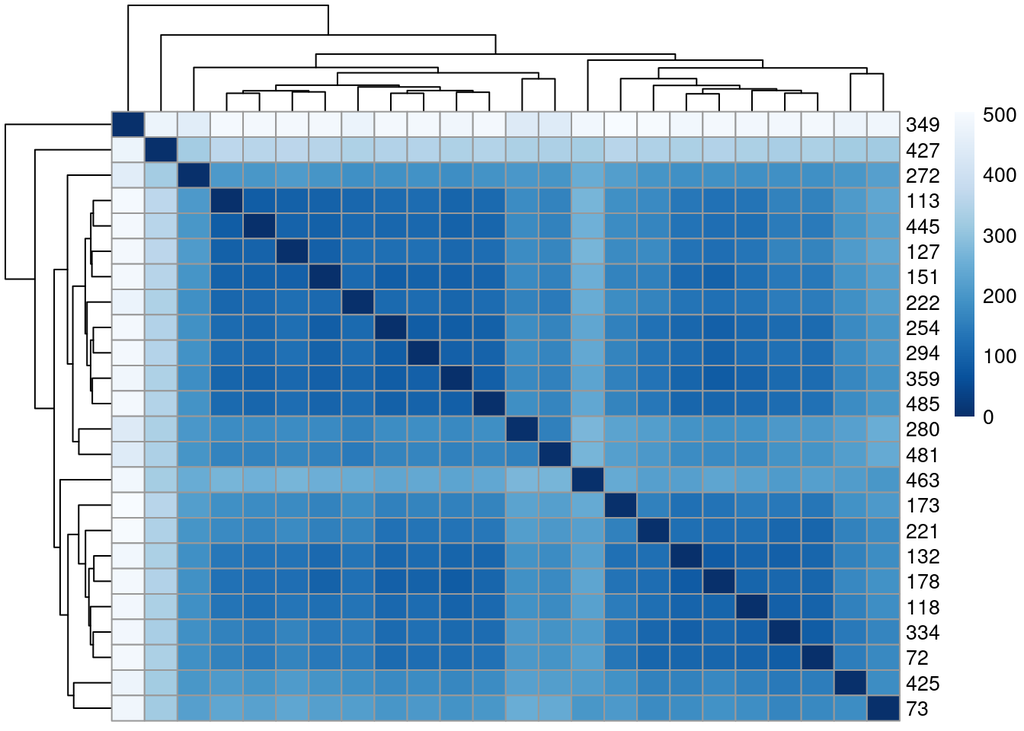

```r
gsampleDists <- dist(t(assay(gvst))) #calculate distance matix
gsampleDistMatrix <- as.matrix(gsampleDists) #distance matrix
rownames(gsampleDistMatrix) <- colnames(gvst) #assign row names
colnames(gsampleDistMatrix) <- NULL #assign col names
colors <- colorRampPalette( rev(brewer.pal(9, "Blues")) )(255) #assign colors
pheatmap(gsampleDistMatrix, #plot matrix
         clustering_distance_rows=gsampleDists, #cluster rows
         clustering_distance_cols=gsampleDists, #cluster columns
         col=colors) #set colors
```

This does not appear to show any distinct groupings.

#### Principal component plot of samples

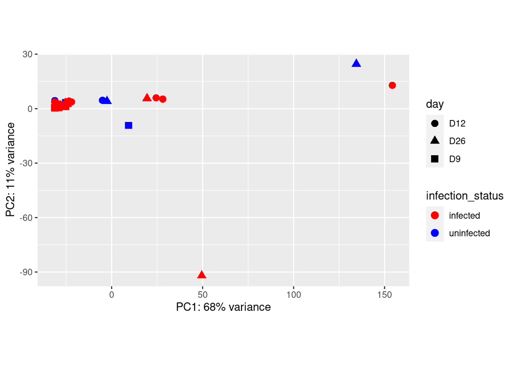

```r
gPCAdata <- plotPCA(gvst, intgroup = c("infection_status", "day"), returnData=TRUE)
percentVar <- round(100*attr(gPCAdata, "percentVar")) #plot PCA of samples with all data
ggplot(gPCAdata, aes(PC1, PC2, color=infection_status, shape=day)) +
  geom_point(size=3) +
  xlab(paste0("PC1: ",percentVar[1],"% variance")) +
  ylab(paste0("PC2: ",percentVar[2],"% variance")) +
  scale_color_manual(values = c(infected="red", uninfected="blue")) +
  coord_fixed()
```

### Differential Gene Expression Analysis

NOTE: This will take a few minutes to run.

```r
DEG.group <- DESeq(gdds, test = "Wald") #run differential expression test by group using Wald (default)
DEG.group.results <- results(DEG.group) #save DE results
resultsNames(DEG.group) #view DE results
```

```
## [1] "Intercept"
## [2] "infection_status_uninfected_vs_infected"
## [3] "day_D26_vs_D12"
## [4] "day_D9_vs_D12"
## [5] "infection_statusuninfected.dayD26"
## [6] "infection_statusuninfected.dayD9"
```

```r
group.results.ordered <- order(DEG.group.results$pvalue) #Order p-values by smallest value first
summary(DEG.group.results) #view results summary
```

```
##
## out of 23065 with nonzero total read count
## adjusted p-value < 0.1
## LFC > 0 (up)       : 60, 0.26%
## LFC < 0 (down)     : 3, 0.013%
## outliers [1]       : 164, 0.71%
## low counts [2]     : 13479, 58%
## (mean count < 4)
## [1] see 'cooksCutoff' argument of ?results
## [2] see 'independentFiltering' argument of ?results
```

```r
sig.num <- sum(DEG.group.results$padj < 0.05, na.rm=TRUE) #How many adjusted p-values were less than 0.05?
sig.num
```

```
## [1] 57
```

### Visualize differentially-expressed genes

```r
DEGs <- subset(DEG.group.results, padj<0.05)
DEGlist <- gdds[which(rownames(gdds) %in% rownames(DEGs))]
print(DEGlist)
```

```
## class: DESeqDataSet
## dim: 57 24
## metadata(1): version
## assays(1): counts
## rownames(57): TRINITY_DN11154_c0_g3 TRINITY_DN11242_c0_g1 ...
##   TRINITY_DN9446_c0_g1 TRINITY_DN9858_c0_g1
## rowData names(0):
## colnames(24): 113 118 ... 72 73
## colData names(4): sample_id day infection_status temperature
```

##### Log-transform the data using a variance stabilizing transforamtion (vst) for visualization purposes, only.

In this instance, have to use `esimateSizeFactors()` outside of typical `vst()` usage because all genes contain a sample with zero. Using `type = "poscounts"` adjusts for this.

Use of `varianceStabilizingTransformation()` instead of `vst()` was recommended in error message by DESeq2.

```r
DEGlist <- estimateSizeFactors(DEGlist, type = "poscounts")
DEGvst <- varianceStabilizingTransformation(DEGlist, blind=FALSE) #apply a variance stabilizing transforamtion to minimize effects of small counts and normalize wrt library size
head(assay(DEGvst), 3) #view transformed gene count data
```

```
##                              113        118        127        132        151
## TRINITY_DN11154_c0_g3 -0.8694319 -0.8694319 -0.8694319 -0.8694319 -0.8694319
## TRINITY_DN11242_c0_g1 -0.8694319 -0.8694319 -0.8694319 -0.8694319 -0.8694319
## TRINITY_DN11251_c0_g1  1.7763074 -0.8694319  0.8652456  3.8245732 -0.8694319
##                              173        178        221        222        254
## TRINITY_DN11154_c0_g3 -0.8694319  2.7245403 -0.8694319 -0.8694319 -0.8694319
## TRINITY_DN11242_c0_g1 -0.8694319 -0.8694319 -0.8694319 -0.8694319 -0.8694319
## TRINITY_DN11251_c0_g1  1.5342868 -0.8694319 -0.8694319 -0.8694319  0.7418464
##                             272      280        294        334      349
## TRINITY_DN11154_c0_g3 1.7210389 1.453616 -0.8694319  2.7422705 2.335552
## TRINITY_DN11242_c0_g1 2.7119217 4.183950 -0.8694319 -0.8694319 3.472217
## TRINITY_DN11251_c0_g1 0.4088579 3.089553 -0.8694319 -0.8694319 2.516804
##                              359        425        427        445        463
## TRINITY_DN11154_c0_g3 -0.8694319 -0.8694319 -0.8694319 -0.8694319 -0.8694319
## TRINITY_DN11242_c0_g1  4.1290024 -0.8694319  1.1369502 -0.8694319 -0.8694319
## TRINITY_DN11251_c0_g1  1.4918697  3.1072396 -0.8694319  3.0524460 -0.8694319
##                              481        485         72       73
## TRINITY_DN11154_c0_g3 -0.8694319 -0.8694319 -0.8694319 2.644090
## TRINITY_DN11242_c0_g1  3.4281416 -0.8694319 -0.8694319 4.074868
## TRINITY_DN11251_c0_g1  3.0785291  3.9641060 -0.8694319 2.681420
```

### Heatmap of differentially-expressed genes

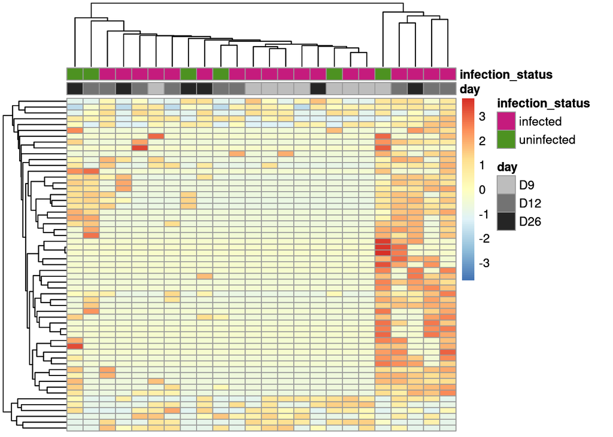

```r
topVarGenes <- head(order(rowVars(assay(DEGvst)),decreasing=TRUE),sig.num) #sort by decreasing sig
mat <- assay(DEGvst)[ topVarGenes, ] #make an expression object
mat <- mat - rowMeans(mat) #difference in expression compared to average across all samples

day_color = c(D9="#BDBDBD", D12="#737373", D26="#252525")
inf_color = c(infected="#C51B7D", uninfected="#4D9221")


ann_colors <-  list(day=day_color, infection_status=inf_color)

df1 <- as.data.frame(colData(DEGvst)[c("day", "infection_status")]) #make dataframe for column naming
DEGheatmap <- pheatmap(mat,
                       scale="row",
                       annotation_col=df1,
                       annotation_colors = ann_colors,
                       clustering_distance_rows="euclidean",
                       clustering_method = "average",
                       show_rownames =FALSE,
                       show_colnames =FALSE,
                       cluster_cols = TRUE
                       )
DEGheatmap
```

### Principal component plot of differentially-expressed genes

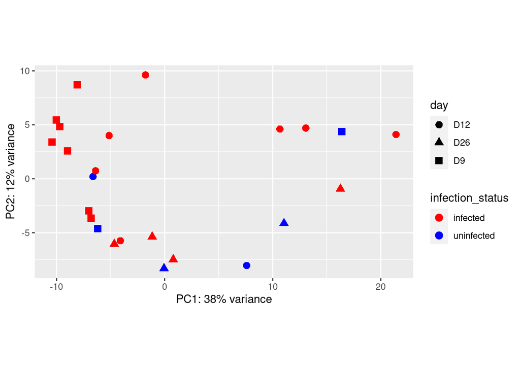

```r
DEGPCAdata <- plotPCA(DEGvst, intgroup = c("infection_status", "day"), returnData=TRUE)
percentVar <- round(100*attr(DEGPCAdata, "percentVar")) #plot PCA of samples with all data
ggplot(DEGPCAdata, aes(PC1, PC2, color=infection_status, shape=day)) +
  geom_point(size=3) +
  xlab(paste0("PC1: ",percentVar[1],"% variance")) +
  ylab(paste0("PC2: ",percentVar[2],"% variance")) +
  scale_color_manual(values = c(infected="red", uninfected="blue")) +
  coord_fixed()
```

[output not shown]